# Data Visualization on Honey Production dataset using seaborn and matplotlib libraries.

### 1. Import required libraries and read the dataset.

```python
import pandas as pd
import numpy as np
import seaborn as sns
import matplotlib.pyplot as plt
import warnings
warnings.filterwarnings("ignore")
```

```python
df = pd.read_csv('honeyproduction.csv')
```

### 2. Check the first few samples, shape, info of the data and try to familiarize yourself with different features.

```python
df.info()
```

```
<class 'pandas.core.frame.DataFrame'>
RangeIndex: 626 entries, 0 to 625
Data columns (total 8 columns):
 #   Column       Non-Null Count  Dtype
---  ------       --------------  -----
 0   state        626 non-null    object
 1   numcol       626 non-null    float64
 2   yieldpercol  626 non-null    int64
 3   totalprod    626 non-null    float64
 4   stocks       626 non-null    float64
 5   priceperlb   626 non-null    float64
 6   prodvalue    626 non-null    float64
 7   year         626 non-null    int64
dtypes: float64(5), int64(2), object(1)
memory usage: 39.2+ KB
```

```python
df.shape
```

```
(626, 8)
```

```python
df.head()
```

|  | state | numcol | yieldpercol | totalprod | stocks | priceperlb | prodvalue | year |
| --- | --- | --- | --- | --- | --- | --- | --- | --- |
| 0 | AL | 16000.0 | 71 | 1136000.0 | 159000.0 | 0.72 | 818000.0 | 1998 |
| 1 | AZ | 55000.0 | 60 | 3300000.0 | 1485000.0 | 0.64 | 2112000.0 | 1998 |
| 2 | AR | 53000.0 | 65 | 3445000.0 | 1688000.0 | 0.59 | 2033000.0 | 1998 |
| 3 | CA | 450000.0 | 83 | 37350000.0 | 12326000.0 | 0.62 | 23157000.0 | 1998 |
| 4 | CO | 27000.0 | 72 | 1944000.0 | 1594000.0 | 0.70 | 1361000.0 | 1998 |

```python
df.describe()
```

|  | numcol | yieldpercol | totalprod | stocks | priceperlb | prodvalue | year |
| --- | --- | --- | --- | --- | --- | --- | --- |
| count | 626.000000 | 626.000000 | 6.260000e+02 | 6.260000e+02 | 626.000000 | 6.260000e+02 | 626.000000 |
| mean | 60284.345048 | 62.009585 | 4.169086e+06 | 1.318859e+06 | 1.409569 | 4.715741e+06 | 2004.864217 |
| std | 91077.087231 | 19.458754 | 6.883847e+06 | 2.272964e+06 | 0.638599 | 7.976110e+06 | 4.317306 |
| min | 2000.000000 | 19.000000 | 8.400000e+04 | 8.000000e+03 | 0.490000 | 1.620000e+05 | 1998.000000 |
| 25% | 9000.000000 | 48.000000 | 4.750000e+05 | 1.430000e+05 | 0.932500 | 7.592500e+05 | 2001.000000 |
| 50% | 26000.000000 | 60.000000 | 1.533000e+06 | 4.395000e+05 | 1.360000 | 1.841500e+06 | 2005.000000 |
| 75% | 63750.000000 | 74.000000 | 4.175250e+06 | 1.489500e+06 | 1.680000 | 4.703250e+06 | 2009.000000 |
| max | 510000.000000 | 136.000000 | 4.641000e+07 | 1.380000e+07 | 4.150000 | 6.961500e+07 | 2012.000000 |

```python
df.describe(include = 'all').T
```

|  | count | unique | top | freq | mean | std | min | 25% | 50% | 75% | max |
| --- | --- | --- | --- | --- | --- | --- | --- | --- | --- | --- | --- |
| state | 626 | 44 | AL | 15 | NaN | NaN | NaN | NaN | NaN | NaN | NaN |
| numcol | 626.0 | NaN | NaN | NaN | 60284.345048 | 91077.087231 | 2000.0 | 9000.0 | 26000.0 | 63750.0 | 510000.0 |
| yieldpercol | 626.0 | NaN | NaN | NaN | 62.009585 | 19.458754 | 19.0 | 48.0 | 60.0 | 74.0 | 136.0 |
| totalprod | 626.0 | NaN | NaN | NaN | 4169086.261981 | 6883846.751268 | 84000.0 | 475000.0 | 1533000.0 | 4175250.0 | 46410000.0 |
| stocks | 626.0 | NaN | NaN | NaN | 1318859.42492 | 2272963.665923 | 8000.0 | 143000.0 | 439500.0 | 1489500.0 | 13800000.0 |
| priceperlb | 626.0 | NaN | NaN | NaN | 1.409569 | 0.638599 | 0.49 | 0.9325 | 1.36 | 1.68 | 4.15 |
| prodvalue | 626.0 | NaN | NaN | NaN | 4715741.214058 | 7976109.76856 | 162000.0 | 759250.0 | 1841500.0 | 4703250.0 | 69615000.0 |
| year | 626.0 | NaN | NaN | NaN | 2004.864217 | 4.317306 | 1998.0 | 2001.0 | 2005.0 | 2009.0 | 2012.0 |

### 3. Display the percentage distribution of the data in each year using the pie chart.

```
 [Text(1.0867325991486694, 0.1703298504302093, '1998'),
 [Text(0.5927632358992742, 0.09290719114375051, '4.9%'),
```

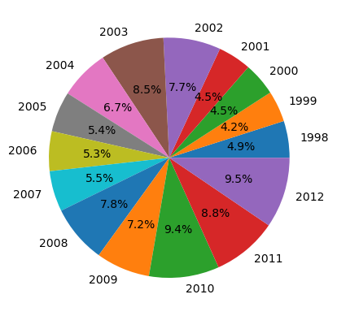

```python
year_prod = df.groupby('year')['prodvalue'].sum()
year= df["year"].unique()
x= year_prod
y= year
plt.pie(x,labels=y,autopct='%1.1f%%')
```

### 4. Plot and Understand the distribution of the variable "price per lb" using displot, and write your findings.

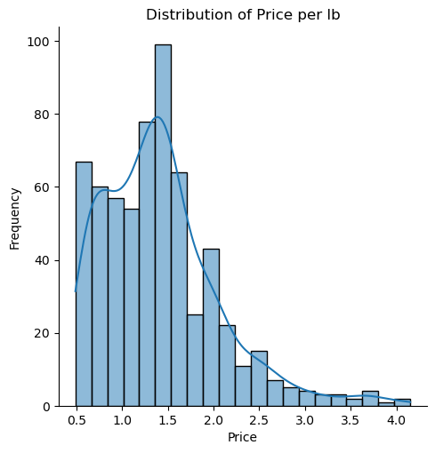

```python
sns.displot(df['priceperlb'], kde=True)
plt.title('Distribution of Price per lb')
plt.xlabel('Price')
plt.ylabel('Frequency')
```

###### 5.From the histogram we can observe that the data is positively skewed

### 5. Plot and understand the relationship between the variables 'numcol' and 'prodval' through scatterplot, and write your findings.

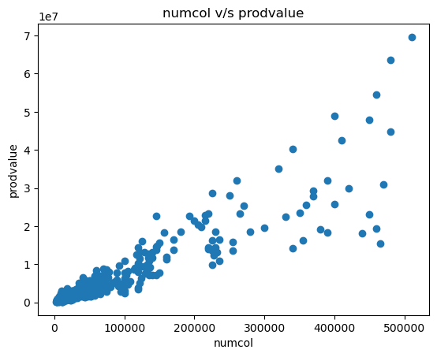

```python
plt.scatter(x=df['numcol'],y=df['prodvalue'])
plt.title('numcol v/s prodvalue')
plt.xlabel('numcol')
plt.ylabel('prodvalue')
```

##### 1. There is positive correlation between both the variables

##### 2. They both are positively correlated

### 6. Plot and understand the relationship between categorical variable 'year' and a numerical variable 'prodvalue' through boxplot, and write your findings.

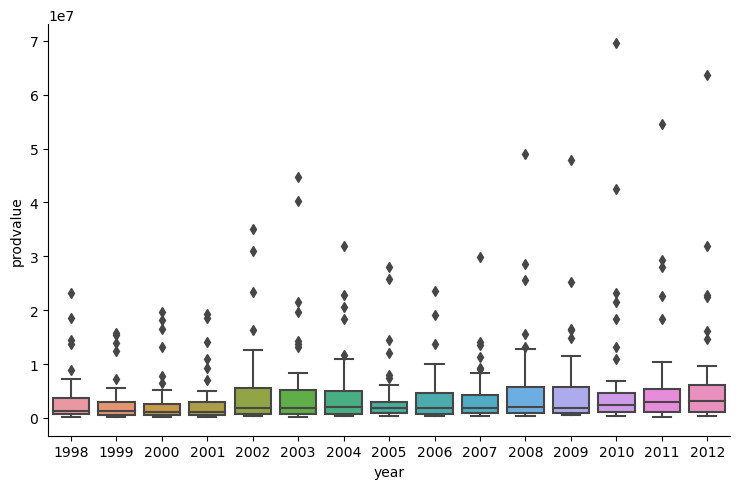

```python
sns.catplot(data=df, x= 'year', y= 'prodvalue',kind='box',height=5,aspect=1.5)
```

##### 1. Every variable has outliers.

##### 2. From the above box plot, we can see that 2010,2011,2012 have higesht production values.

##### 3. The production values highly varies from the median vales.

### 7. Visualize and understand the relationship between the multiple pairs of variables throughout different years using pairplot and add your inferences. (use columns 'numcol', 'yield percol', 'total prod', 'prodvalue','year')

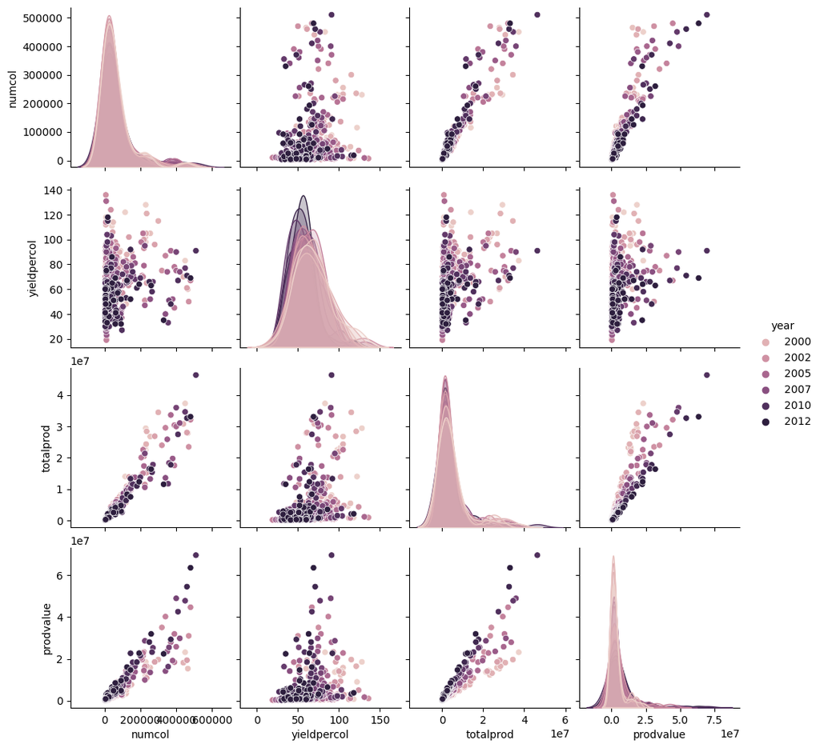

```python
sns.pairplot(df[['numcol', 'yieldpercol', 'totalprod', 'prodvalue','year']], hue='year');
```

##### 1. The datas of 'numcol', 'totalprod' and 'prodvalue' are positively skewed.

##### 2. Data in 'yieldpercol' seems to be normally distributed\

##### 3. As the total production increases, the production value and stocks are also increases.

### 8. Display the correlation values using a plot and add your inferences. (use columns 'numcol', 'yield percol', 'total prod', 'stocks', 'price per lb', 'prodvalue')

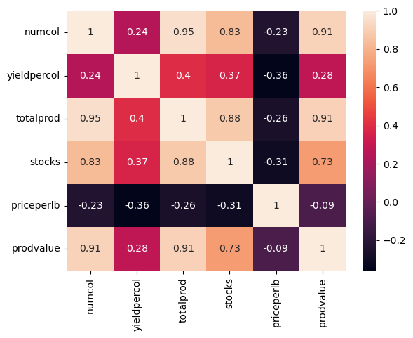

```python
sns.heatmap(data=df[['numcol', 'yieldpercol', 'totalprod', 'stocks', 'priceperlb', 'prodvalue']].corr(),annot=True)
```

##### 4. The relationship between total production and production value is positive correlation and correlation value is 0.91.

##### 5. The relationship between total production and stocks is positive correlation and correlation value is 0.88.

##### 6. The relationship between stocks and production value is positive correlation and correlation value is 0.73.

##### 7. Priceperlb and yieldpercol are weakly negatively correlated, with a corelation of -0.36.

##### 8. Priceperlb has a negative corelation with every variables.